# 1. Introdução

Esse EDA será feito em cima de um dataset da LEGO obtido no kaggle. As informações são sobre todos os produtos produzidos pela empresa, desde a primeira peça em 1950 até 2017.

[figure not shown]

# 2.Cores

Primeiro analisar a quantidade diferente de cores já produzidas. Carregando a planilha 'colors.csv'

```python
import pandas as pd

colors = pd.read_csv('colors.csv')

colors.head()
```

|  | id | name | rgb | is_trans |
| --- | --- | --- | --- | --- |
| 0 | -1 | Unknown | 0033B2 | f |
| 1 | 0 | Black | 05131D | f |
| 2 | 1 | Blue | 0055BF | f |
| 3 | 2 | Green | 237841 | f |
| 4 | 3 | Dark Turquoise | 008F9B | f |

```python
num_colors = colors['name'].nunique()

print('O número de cores diferentes é ', num_colors)
```

```
O número de cores diferentes é  135
```

## Cores transparentes

As cores podem ser divididas entre transparentes ou não.

```python
colors_summary = colors.groupby('is_trans', as_index = False).count()
```

```python
import matplotlib.pyplot as plt

plt.bar(colors_summary.is_trans,colors_summary.id, color=['dodgerblue','lightgreen'])
```

[output not shown]

```
<BarContainer object of 2 artists>
```

Como era de se esperar, as cores não transparentes são maior número.

# 3.Conjuntos

Agora vamos analisar os conjuntos, utilizando o arquivo sets.csv

Nele contém a informação sobre os conjuntos que foram lançados ao longo dos anos e o número de peças que eles contém.

```python
sets = pd.read_csv('sets.csv')

sets.head()
```

|  | set_num | name | year | theme_id | num_parts |
| --- | --- | --- | --- | --- | --- |
| 0 | 00-1 | Weetabix Castle | 1970 | 414 | 471 |
| 1 | 0011-2 | Town Mini-Figures | 1978 | 84 | 12 |
| 2 | 0011-3 | Castle 2 for 1 Bonus Offer | 1987 | 199 | 2 |
| 3 | 0012-1 | Space Mini-Figures | 1979 | 143 | 12 |
| 4 | 0013-1 | Space Mini-Figures | 1979 | 143 | 12 |

Vamos analisar quantos conjuntos são lançados a cada ano.

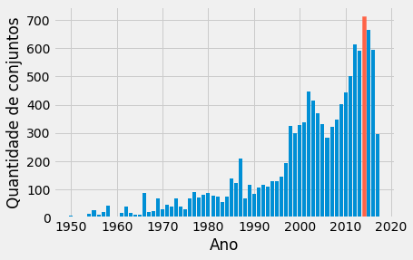

```python
sets_by_year = sets[['year', 'set_num']].groupby('year',as_index = False).count()

plt.style.use('fivethirtyeight')

barlist = plt.bar(sets_by_year['year'],sets_by_year['set_num'])
barlist[62].set_color('tomato')
plt.xlabel('Ano')
plt.ylabel('Quantidade de conjuntos')
plt.show()
```

Observamos que o ano 2014 foi o ano com maior lançamento de conjuntos, 713.

O que é interessante observar que esse ano foi o lançamento de:

[figure not shown]

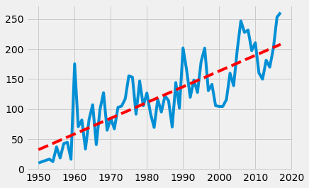

```python
import numpy as np
# numero medio de partes
parts_by_year = sets[['year', 'num_parts']].groupby('year',as_index = False).mean()

plt.style.use('fivethirtyeight')

x = parts_by_year['year']
y = parts_by_year['num_parts']
plt.plot(x, y)

z = np.polyfit(x, y, 1)
p = np.poly1d(z)
plt.plot(x,p(x),"r--")

plt.show()
```

Vemos uma tendência de aumento do número médio de peças em cada conjunto lançado.

Provavelmente o número total de peças e a complexidade também aumentou.

Vamos ver agora os conjuntos com mais peças.

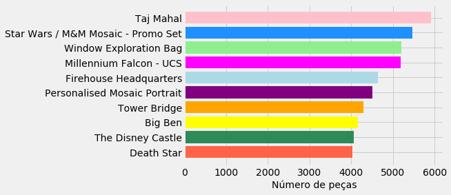

```python
most_parts = sets[['name', 'year', 'num_parts']].nlargest(10, 'num_parts')

most_parts = most_parts.sort_values('num_parts')

plt.style.use('fivethirtyeight')

plt.barh(most_parts['name'],most_parts['num_parts'],
         color = ['tomato','seagreen','yellow','orange','purple','lightblue','magenta','lightgreen','dodgerblue','pink'] )
plt.xlabel('Número de peças', fontsize = 14)
plt.show()
```

# 4.Coleções

Os conjuntos também são agrupados por coleções.

A seguir uma análise das coleções por ano

```python
themes = pd.read_csv('themes.csv')

themes.head()
```

|  | id | name | parent_id |
| --- | --- | --- | --- |
| 0 | 1 | Technic | NaN |
| 1 | 2 | Arctic Technic | 1.0 |
| 2 | 3 | Competition | 1.0 |
| 3 | 4 | Expert Builder | 1.0 |
| 4 | 5 | Model | 1.0 |

Essa base traz apenas o nome das coleções.

Para trabalhar com essa ela teremos que juntar com a base 'sets'

```python
themes = themes[['id','name']]
themes = themes.rename(columns={'id':'theme_id','name':'theme_name'})
```

```python
lego_themes = pd.merge(sets,themes,on='theme_id')

lego_themes.head()
```

|  | set_num | name | year | theme_id | num_parts | theme_name |
| --- | --- | --- | --- | --- | --- | --- |
| 0 | 00-1 | Weetabix Castle | 1970 | 414 | 471 | Castle |
| 1 | 0011-2 | Town Mini-Figures | 1978 | 84 | 12 | Supplemental |
| 2 | 2181-1 | Infomaniac | 1997 | 84 | 4 | Supplemental |
| 3 | 300-1 | T-Junction Road Plates | 1978 | 84 | 2 | Supplemental |
| 4 | 301-1 | Curved Road Plates | 1978 | 84 | 2 | Supplemental |

```python
# numero de sets por themes

sets_themes = pd.DataFrame(lego_themes['theme_name'].value_counts())

most_sets = sets_themes.nlargest(10,'theme_name')

most_sets
```

|  | theme_name |
| --- | --- |
| Supplemental | 496 |
| Technic | 435 |
| City | 287 |
| Friends | 269 |
| Basic Set | 257 |
| Creator | 249 |
| Gear | 246 |
| Service Packs | 242 |
| Duplo | 219 |
| Star Wars | 211 |

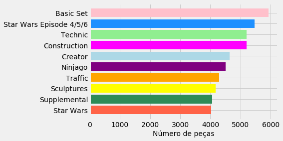

```python
themes_parts = lego_themes[['theme_name','num_parts']].groupby('theme_name', as_index=False).sum()

themes_parts = themes_parts.nlargest(10, 'num_parts')

themes_parts = themes_parts.sort_values('num_parts')

plt.style.use('fivethirtyeight')

plt.barh(themes_parts['theme_name'],most_parts['num_parts'],
         color = ['tomato','seagreen','yellow','orange','purple','lightblue','magenta','lightgreen','dodgerblue','pink'] )
plt.xlabel('Número de peças', fontsize = 14)
plt.show()
```